# Projection Operators

Author

Anonymous

Published

2026-04-07

# Set up

Read in data and scales:

```r
task_df <- read_rds(here("data", "part1", "task.rds"))
participants <- read_rds(here("data", "part1", "participants.rds"))
exp1_x <- make_va_scale(data_min = -5, data_max = 5, px_min = 50, px_max = 585)
exp1_y <- make_va_scale(data_min = 0, data_max = 1, px_min = 410, px_max = 15)
```

# `ProjectToAxis`: Project from dot to axes

We denote this task as `task5` in the configuration file. First, we get the data:

```r
task5_df <- task_df %>%
  filter(task == "task5") %>%
  select(
    participantId,
    task,
    id,
    data.select.x,
    data.select.y,
    slider.x,
    slider.y
  ) %>%
  rename(
    data.ans.x = data.select.x,
    data.ans.y = data.select.y,
    data.resp.x = slider.x,
    data.resp.y = slider.y
  ) %>%
  right_join(participants, by = join_by(participantId)) %>%
  # convert from data space to visual angle space
  mutate(
    va.resp.x = exp1_x$data_to_va(data.resp.x, dist_to_screen, pixelToMM),
    va.resp.y = exp1_y$data_to_va(data.resp.y, dist_to_screen, pixelToMM),
    va.ans.x = exp1_x$data_to_va(data.ans.x, dist_to_screen, pixelToMM),
    va.ans.y = exp1_y$data_to_va(data.ans.y, dist_to_screen, pixelToMM),
  )
```

## `ProjectToAxisX`: Project to X-Axis

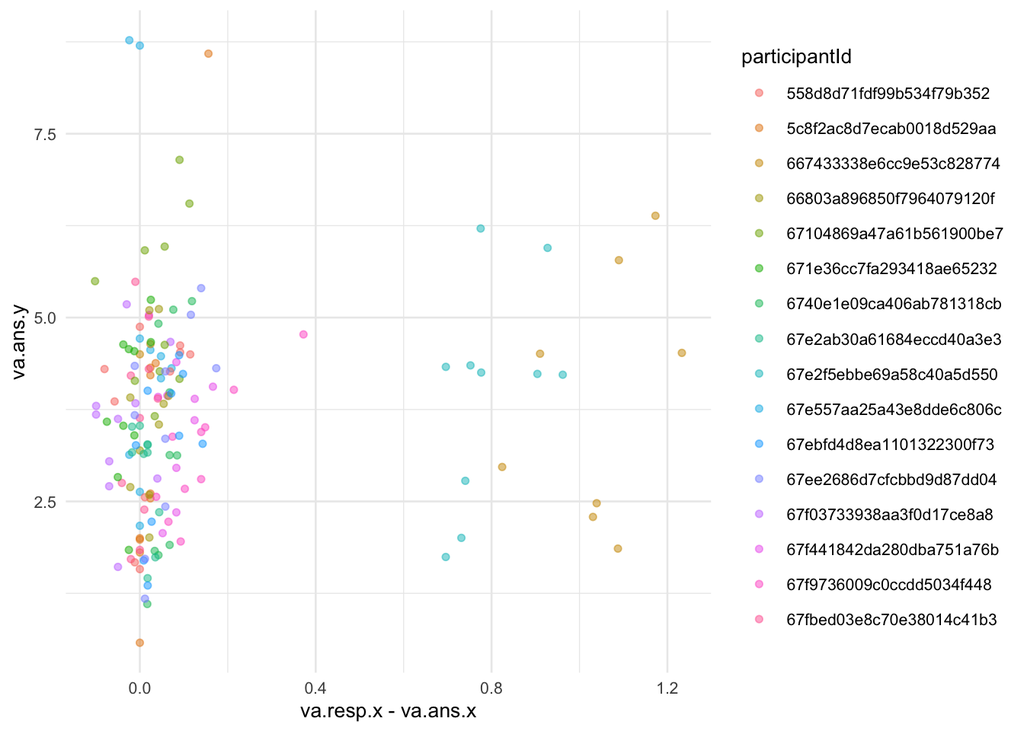

```r
task5_df %>%
  ggplot(aes(y = va.ans.y, x = va.resp.x - va.ans.x, color = participantId)) +
  geom_point(alpha = 0.5)
```

```r
task5_df %>%
  filter(va.resp.x - va.ans.x > 0.4) %>%
  count(participantId) %>%
  left_join(participants, by = join_by(participantId))
```

| participantId | n | pixelToMM | dist_to_screen |
| --- | --- | --- | --- |
| 667433338e6cc9e53c828774 | 8 | 4.082353 | 617.6327 |
| 67e2f5ebbe69a58c40a5d550 | 10 | 4.705882 | 560.5799 |

As can be seen, there are two participants, who have `va.resp.x - va.ans.x` > 0.4. Let’s also plot what the actual selected answers in data space is:

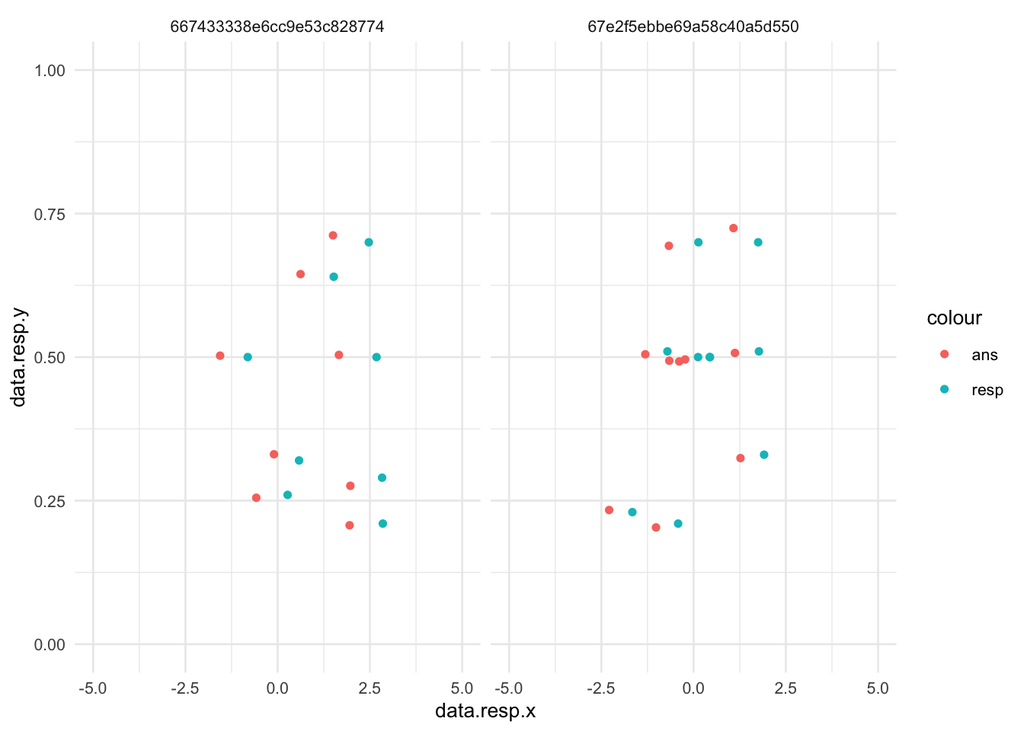

```r
task5_df %>%
  filter(va.resp.x - va.ans.x > 0.4) %>%
  ggplot() +
  geom_point(aes(x = data.resp.x, y = data.resp.y, color = "resp")) +
  geom_point(aes(x = data.ans.x, y = data.ans.y, color = "ans")) +
  facet_wrap(~participantId) +
  xlim(-5, 5) +
  ylim(0, 1)
```

Recall that we are dealing with data that is already cleaned, so why are we still seeing data that is slightly shifted towards the right, for answers on the X-axis? Turns out these two participants were aligning things wrongly on the slider (i.e, they did not match the blue dot to the red dot but matched the thing on the slider to the red dot), hence the shift in their answers. **Thus, we exclude these two participants from our analysis for task 5**:

```r
task5.x.exclude <- c("667433338e6cc9e53c828774", "67e2f5ebbe69a58c40a5d550")
```

Math model:

$$\begin{align}
\texttt{error}_i &\sim \mathcal{N}(\mu_{\text{PID}[i]}, \sigma_{i, \text{PID}[i]}) \\
\log(\sigma_{i, j}) &= \alpha_j + \log(\texttt{va.ans.y}_i) \\
\mu_j &\sim \mathcal{N}(\overline{\mu}, \overline{\sigma}^2)\\
\alpha_j &\sim N(\mu_\alpha, \sigma_\alpha) \\
\mu_\alpha, \bar{\mu} &\sim N(0, 1) \\
\sigma_\alpha, \bar{\sigma} &\sim \mathcal{N}^+(0, 1)
\end{align}$$

Specify formula and prior:

```r
f <- bf(
  error_va ~ 1 + (1 | participantId),
  sigma ~ 1 + (1 | participantId) + offset(log(va.ans.y))
)

p <- c(
  prior(normal(0, 1), class = Intercept),
  prior(normal(0, 1), class = sd, group = participantId, lb = 0),
  prior(normal(0, 1), class = Intercept, dpar = "sigma"),
  prior(normal(0, 1), class = sd, group = participantId, dpar = "sigma", lb = 0)
)
```

Fit model:

```r
m.5.x.va <- task5_df %>%
  mutate(error_va = va.resp.x - va.ans.x) %>%
  # exclude the two participants who answered this task wrong
  filter(!participantId %in% task5.x.exclude) %>%
  brm(
    formula = f,
    data = .,
    family = gaussian(),
    prior = p,
    chains = 4,
    cores = 4,
    control = list(adapt_delta = 0.99),
    iter = 6000,
    file = here("analysis", "fitted_models", "part1", "task5.x"),
    file_refit = "on_change",
    save_pars = save_pars(all = TRUE)
  )
```

Check fit and posterior:

```r
summary(m.5.x.va)
```

```
 Family: gaussian
  Links: mu = identity; sigma = log
Formula: error_va ~ 1 + (1 | participantId)
         sigma ~ 1 + (1 | participantId) + offset(log(va.ans.y))
   Data: . (Number of observations: 140)
  Draws: 4 chains, each with iter = 6000; warmup = 3000; thin = 1;
         total post-warmup draws = 12000

Multilevel Hyperparameters:
~participantId (Number of levels: 14)
                    Estimate Est.Error l-95% CI u-95% CI Rhat Bulk_ESS Tail_ESS
sd(Intercept)           0.04      0.01     0.02     0.06 1.00     2919     4846
sd(sigma_Intercept)     0.36      0.12     0.17     0.65 1.00     3612     4672

Regression Coefficients:
                Estimate Est.Error l-95% CI u-95% CI Rhat Bulk_ESS Tail_ESS
Intercept           0.02      0.01    -0.00     0.04 1.00     2202     3894
sigma_Intercept    -4.35      0.13    -4.59    -4.08 1.00     4252     4413

Draws were sampled using sample(hmc). For each parameter, Bulk_ESS
and Tail_ESS are effective sample size measures, and Rhat is the potential
scale reduction factor on split chains (at convergence, Rhat = 1).
```

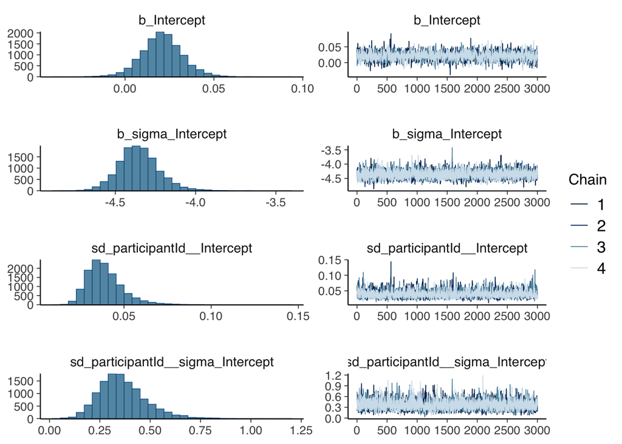

```r
plot(m.5.x.va)
```

Posterior predictive checks:

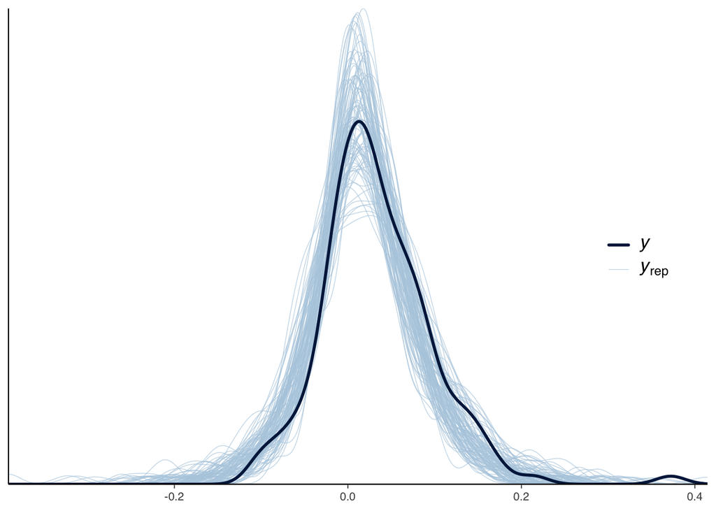

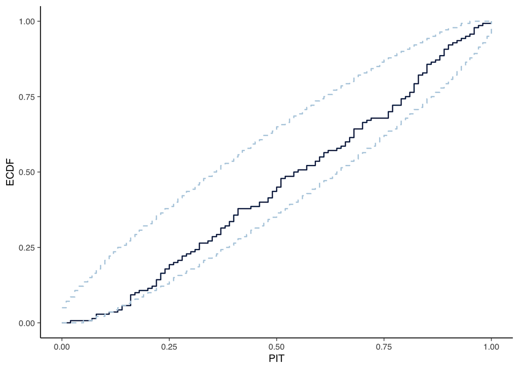

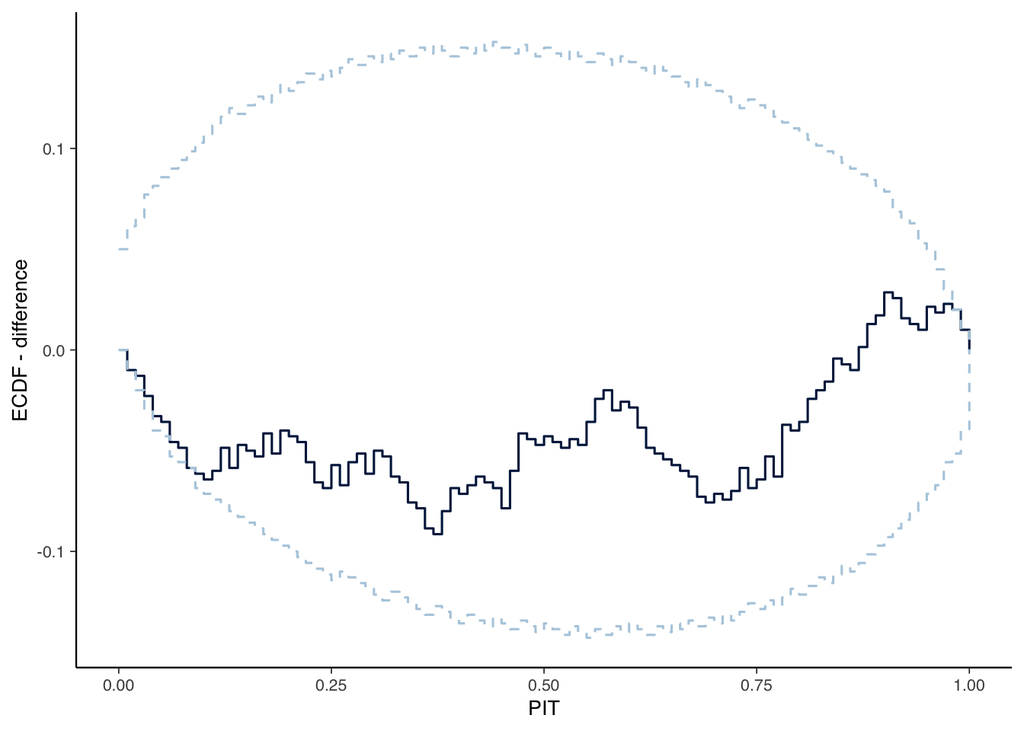

```r
pp_check(m.5.x.va, ndraws = 100) +
  theme(legend.position = c(0.9, 0.5)) +
  theme(text = element_text(size = 10)) -> p1
p1
pp_check(m.5.x.va, ndraws = 100, type = "pit_ecdf") +
  theme(text = element_text(size = 10)) -> p2
p2
pp_check(m.5.x.va, ndraws = 100, type = "pit_ecdf", plot_diff = TRUE) +
  theme(text = element_text(size = 10)) -> p3
p3
```

Plot existing data on top of prediction:

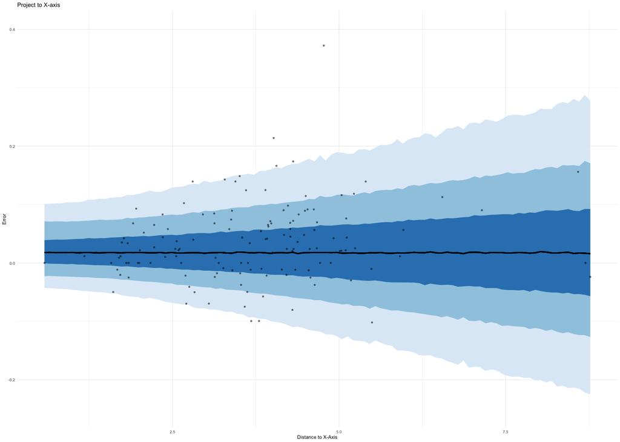

```r
# for an average participant

prediction_grid <- task5_df %>%
  mutate(error_va = va.resp.x - va.ans.x) %>%
  filter(!participantId %in% task5.x.exclude) %>%
  data_grid(
    va.ans.y = seq_range(va.ans.y, n = 100),
    participantId = unique(participantId)
  ) %>%
  add_predicted_draws(m.5.x.va, ndraws = 1000)

ggplot(prediction_grid, aes(x = va.ans.y, y = .prediction)) +
  stat_lineribbon(
    .width = c(.95, .80, .50),
    # alpha = 0.5,
    linewidth = 0.5
  ) +
  scale_fill_brewer(palette = "Blues") +
  geom_point(
    data = filter(task5_df, !participantId %in% task5.x.exclude),
    aes(y = va.resp.x - va.ans.x, x = va.ans.y),
    alpha = 0.5,
    size = 0.5
  ) +
  labs(
    title = "Project to X-axis",
    y = "Error",
    x = "Distance to X-Axis"
  ) +
  # theme_minimal(base_size = 8) +
  coord_cartesian(ylim = c(-0.25, 0.4)) +
  theme_minimal(base_size = 4) +
  theme(legend.position = "none") -> p1

p1
```

## `ProjectToAxisY`

This time we look at error on $y$-axis:

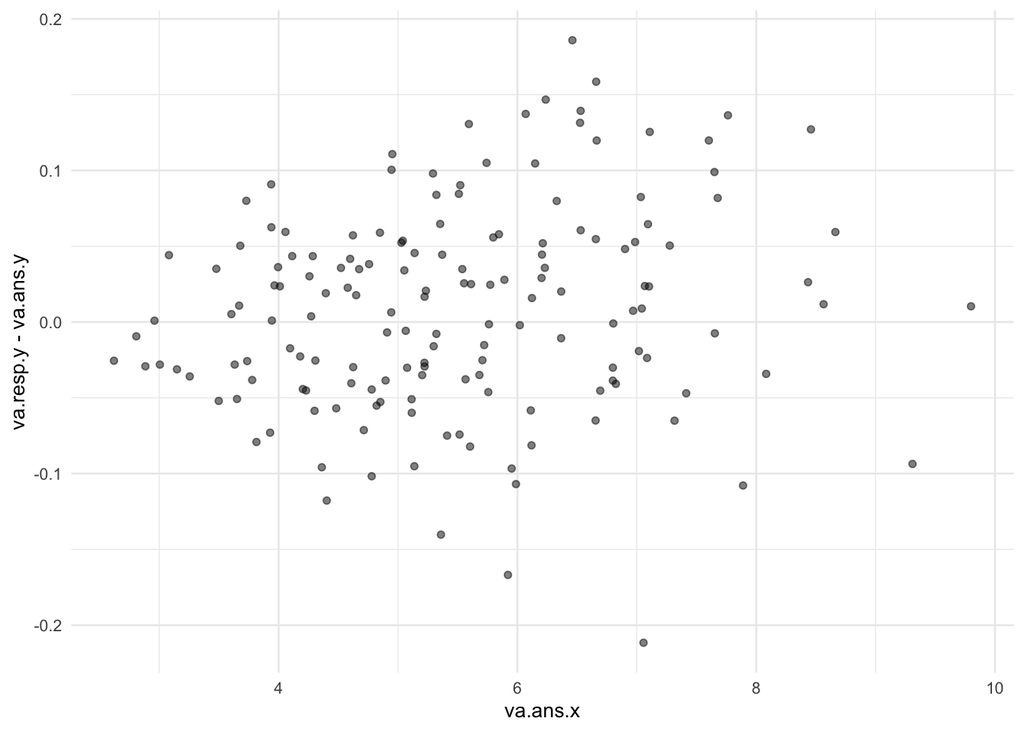

```r
task5_df %>%
  ggplot(aes(x = va.ans.x, y = va.resp.y - va.ans.y)) +
  geom_point(alpha = 0.5)
```

We use a similar math model to the first part:

$$\begin{align*}
\texttt{error}_i &\sim \mathcal{N}(\mu_{\text{PID}[i]}, \sigma_{i, \text{PID}[i]}) \\
\log(\sigma_{i, j}) &= \alpha_j + \log(\texttt{va.ans.x}_i) \\
\alpha_j &\sim N(\mu_\alpha, \sigma_\alpha) \\
\mu_\alpha &\sim N(0, 1) \\
\sigma_\alpha &\sim N^+(0, 1)
\end{align*}$$

Which corresponds to this `brms` formula and prior:

```r
f <- bf(
  error_va ~ 1 + (1 | participantId),
  sigma ~ 1 + (1 | participantId) + offset(log(va.ans.x))
)

p <- c(
  prior(normal(0, 1), class = Intercept),
  prior(normal(0, 1), class = sd, group = participantId, lb = 0),
  prior(normal(0, 1), class = Intercept, dpar = "sigma"),
  prior(normal(0, 1), class = sd, group = participantId, dpar = sigma, lb = 0)
)
```

Fit model:

```r
m.5.y.va <- task5_df %>%
  mutate(error_va = va.resp.y - va.ans.y) %>%
  brm(
    formula = f,
    data = .,
    family = gaussian(),
    prior = p,
    chains = 4,
    cores = 4,
    control = list(adapt_delta = 0.99),
    iter = 6000,
    file = here("analysis", "fitted_models", "part1", "task5.y"),
    file_refit = "on_change",
    save_pars = save_pars(all = TRUE)
  )
```

Check fit and posterior:

```r
summary(m.5.y.va)
```

```
 Family: gaussian
  Links: mu = identity; sigma = log
Formula: error_va ~ 1 + (1 | participantId)
         sigma ~ 1 + (1 | participantId) + offset(log(va.ans.x))
   Data: . (Number of observations: 160)
  Draws: 4 chains, each with iter = 6000; warmup = 3000; thin = 1;
         total post-warmup draws = 12000

Multilevel Hyperparameters:
~participantId (Number of levels: 16)
                    Estimate Est.Error l-95% CI u-95% CI Rhat Bulk_ESS Tail_ESS
sd(Intercept)           0.04      0.01     0.03     0.07 1.00     2477     4702
sd(sigma_Intercept)     0.31      0.11     0.13     0.56 1.00     3135     2634

Regression Coefficients:
                Estimate Est.Error l-95% CI u-95% CI Rhat Bulk_ESS Tail_ESS
Intercept           0.00      0.01    -0.02     0.03 1.00     2618     4011
sigma_Intercept    -4.63      0.11    -4.83    -4.41 1.00     4867     4506

Draws were sampled using sample(hmc). For each parameter, Bulk_ESS
and Tail_ESS are effective sample size measures, and Rhat is the potential
scale reduction factor on split chains (at convergence, Rhat = 1).
```

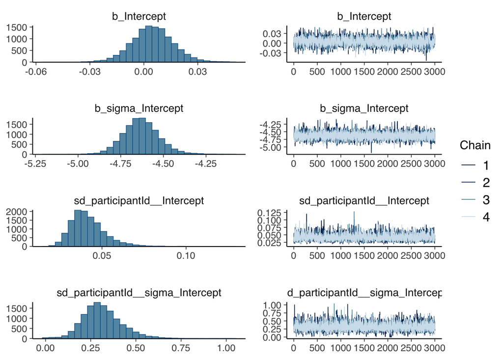

```r
plot(m.5.y.va)
```

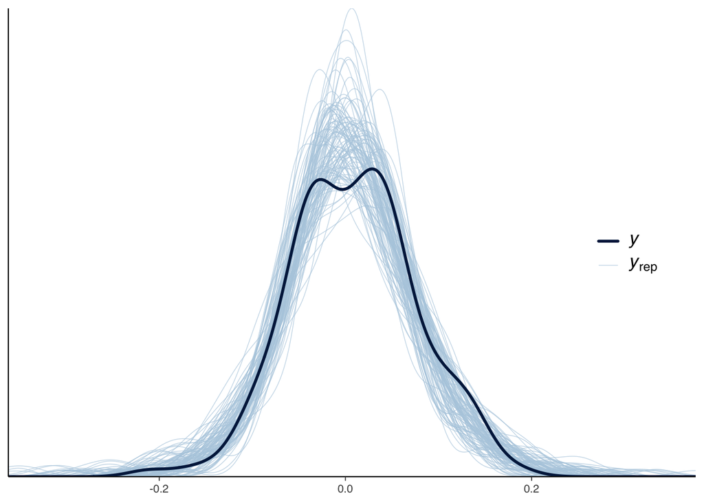

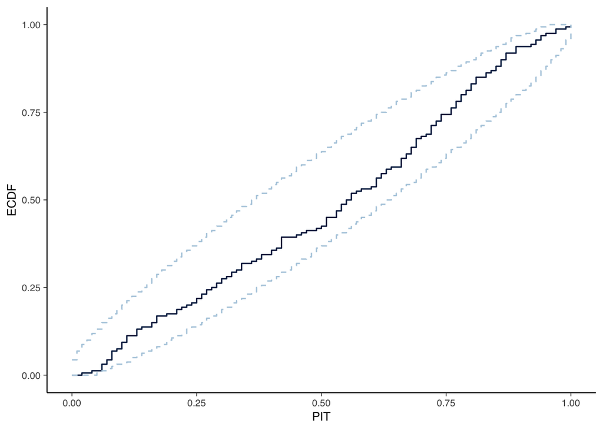

```r
pp_check(m.5.y.va, ndraws = 100) +
  theme(text = element_text(size = 10)) +
  theme(legend.position = c(0.9, 0.5)) -> p1

pp_check(m.5.y.va, ndraws = 100, type = "pit_ecdf") +
  theme(text = element_text(size = 10)) -> p2

p1
p2
```

Plot results:

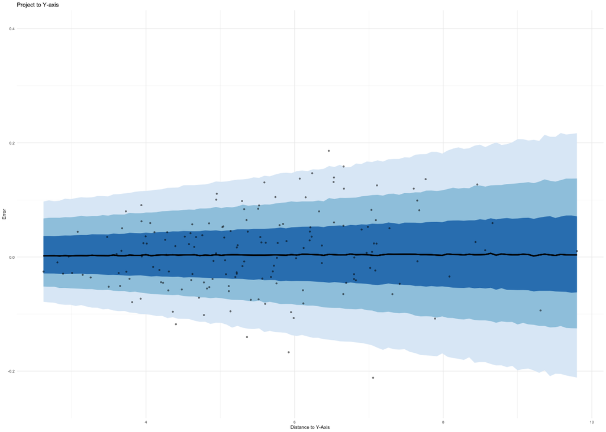

```r
prediction_grid <- task5_df %>%
  data_grid(
    va.ans.x = seq_range(va.ans.x, n = 100),
    participantId = unique(participantId)
  ) %>%
  add_predicted_draws(m.5.y.va, ndraws = 1000)

ggplot(prediction_grid, aes(x = va.ans.x, y = .prediction)) +
  stat_lineribbon(
    .width = c(.95, .80, .50),
    # alpha = 0.5,
    linewidth = 0.5
  ) +
  scale_fill_brewer(palette = "Blues") +
  geom_point(
    data = task5_df,
    aes(y = va.resp.y - va.ans.y, x = va.ans.x),
    alpha = 0.5,
    size = 0.5
  ) +
  coord_cartesian(ylim = c(-0.25, 0.4)) +
  labs(
    title = "Project to Y-axis",
    y = "Error",
    x = "Distance to Y-Axis"
  ) +
  # theme_minimal(base_size = 8) +
  theme_minimal(base_size = 4) +
  theme(legend.position = "none") -> p2

p2
```

# `ProjectToCurve`: Project from where y == 0.5 to Curve

We denote this as `task 3` in the configuration json. First, we get task 3 specific data:

```r
task3_df <- task_df %>%
  filter(task == "task3") %>%
  select(-slider.x, -slider.y) %>%
  right_join(participants, by = join_by(participantId)) %>%
  mutate(
    data.ans.y = 0.5,
    data.ans.x = qsgt(
      0.5,
      param.mu,
      param.sigma,
      param.lambda,
      param.p,
      param.q,
      mean.cent = FALSE
    )
  ) %>%
  # do all the calculations for the actual answer
  mutate(
    va.resp.x = exp1_x$data_to_va(data.select.x, dist_to_screen, pixelToMM),
    va.resp.y = exp1_y$data_to_va(data.select.y, dist_to_screen, pixelToMM),
    va.ans.x = exp1_x$data_to_va(data.ans.x, dist_to_screen, pixelToMM),
    va.ans.y = exp1_y$data_to_va(data.ans.y, dist_to_screen, pixelToMM)
  )
```

Descriptive plots:

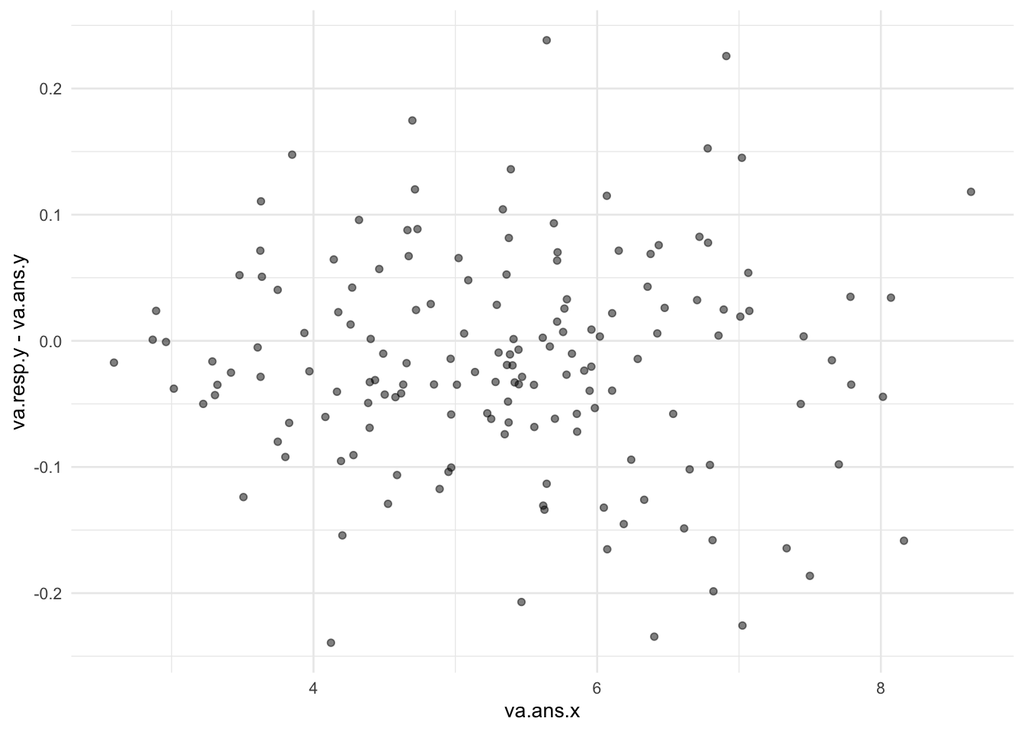

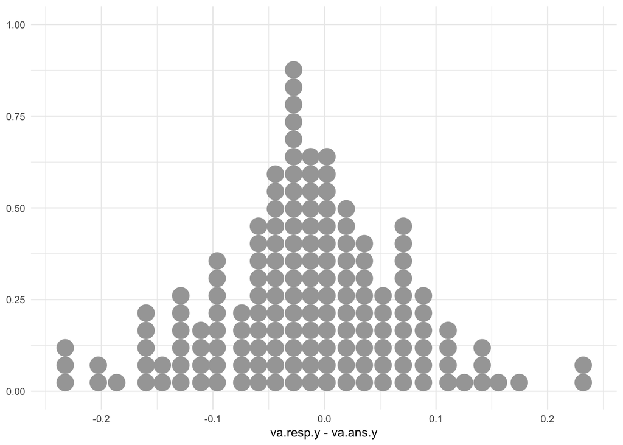

```r
task3_df %>%
  ggplot(aes(x = va.ans.x, y = va.resp.y - va.ans.y)) +
  geom_point(alpha = 0.5)
task3_df %>% ggplot(aes(x = va.resp.y - va.ans.y)) + geom_dots()
```

Math model:

$$\begin{align*}
\texttt{error}_i &\sim \mathcal{N}(\mu_{\text{PID}[i]}, \sigma_{i, \text{PID}[i]}) \\
\log(\sigma_{i, j}) &= \alpha_j + \log(\texttt{va.ans.x}_i) \\
\mu_j &\sim \mathcal{N}(\mu_\mu, \sigma_\mu) \\
\alpha_j &\sim N(\mu_\alpha, \sigma_\alpha) \\
\mu_\mu, \mu_\alpha &\sim N(0, 1) \\
\sigma_mu, \sigma_\alpha &\sim N^+(0, 1)
\end{align*}$$

`brms` formula and prior:

```r
f <- bf(
  error_va ~ (1 | participantId),
  sigma ~ (1 | participantId) + offset(log(va.ans.x))
)

p <- c(
  prior(normal(0, 1), class = Intercept),
  prior(normal(0, 1), class = sd, group = participantId, lb = 0),
  prior(normal(0, 1), class = Intercept, dpar = "sigma"),
  prior(normal(0, 1), class = sd, group = participantId, dpar = sigma, lb = 0)
)
```

Fit model:

```r
m3 <- task3_df %>%
  mutate(error_va = va.resp.y - va.ans.y, log.va.ans.x = log(va.ans.x)) %>%
  brm(
    formula = f,
    data = .,
    family = gaussian(),
    prior = p,
    chains = 4,
    cores = 4,
    file = here("analysis", "fitted_models", "part1", "task3"),
    file_refit = "on_change",
    save_pars = save_pars(all = TRUE),
    control = list(adapt_delta = 0.99),
    iter = 6000
  )
```

Check fit and posterior:

```r
summary(m3)
```

```
 Family: gaussian
  Links: mu = identity; sigma = log
Formula: error_va ~ (1 | participantId)
         sigma ~ (1 | participantId) + offset(log(va.ans.x))
   Data: . (Number of observations: 160)
  Draws: 4 chains, each with iter = 6000; warmup = 3000; thin = 1;
         total post-warmup draws = 12000

Multilevel Hyperparameters:
~participantId (Number of levels: 16)
                    Estimate Est.Error l-95% CI u-95% CI Rhat Bulk_ESS Tail_ESS
sd(Intercept)           0.05      0.01     0.04     0.08 1.00     3165     5506
sd(sigma_Intercept)     0.50      0.13     0.30     0.81 1.00     3467     5211

Regression Coefficients:
                Estimate Est.Error l-95% CI u-95% CI Rhat Bulk_ESS Tail_ESS
Intercept          -0.01      0.01    -0.04     0.02 1.00     2369     4241
sigma_Intercept    -4.46      0.15    -4.72    -4.15 1.00     3124     3855

Draws were sampled using sample(hmc). For each parameter, Bulk_ESS
and Tail_ESS are effective sample size measures, and Rhat is the potential
scale reduction factor on split chains (at convergence, Rhat = 1).
```

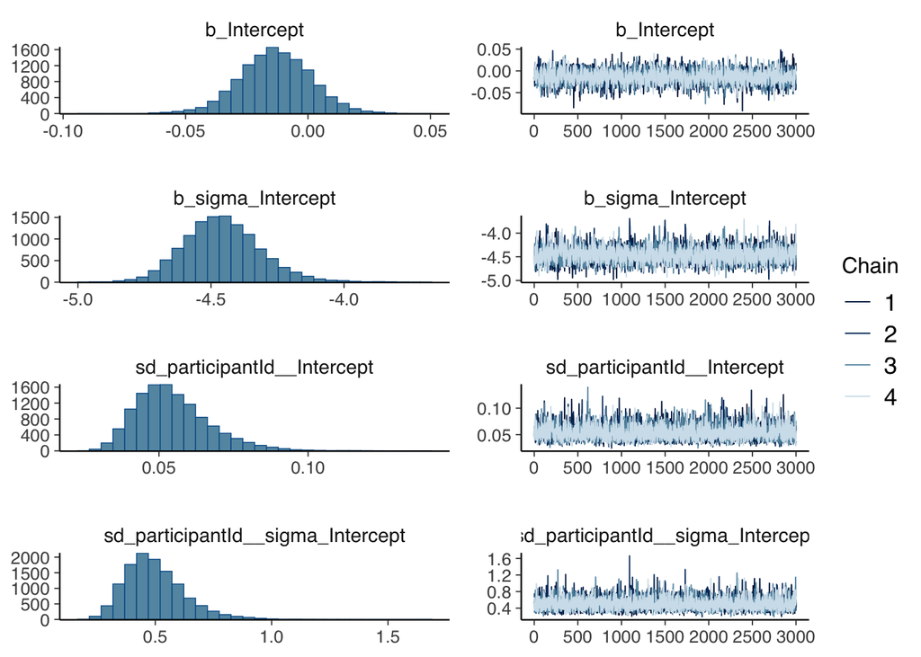

```r
plot(m3)
```

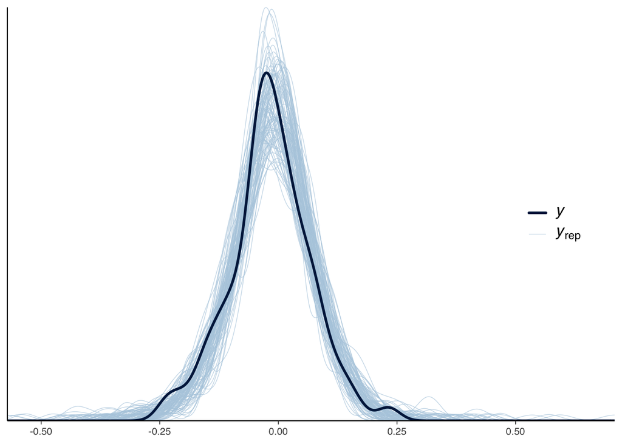

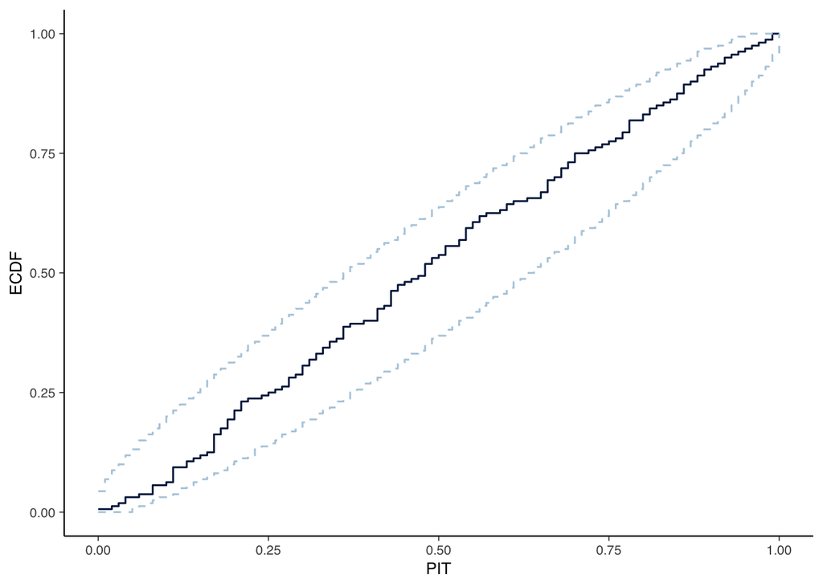

```r
pp_check(m3, ndraws = 100) +
  theme(text = element_text(size = 10)) +
  theme(legend.position = c(0.9, 0.5)) -> p1

pp_check(m3, ndraws = 100, type = "pit_ecdf") +
  theme(text = element_text(size = 10)) -> p2

p1
p2
```

Plot result:

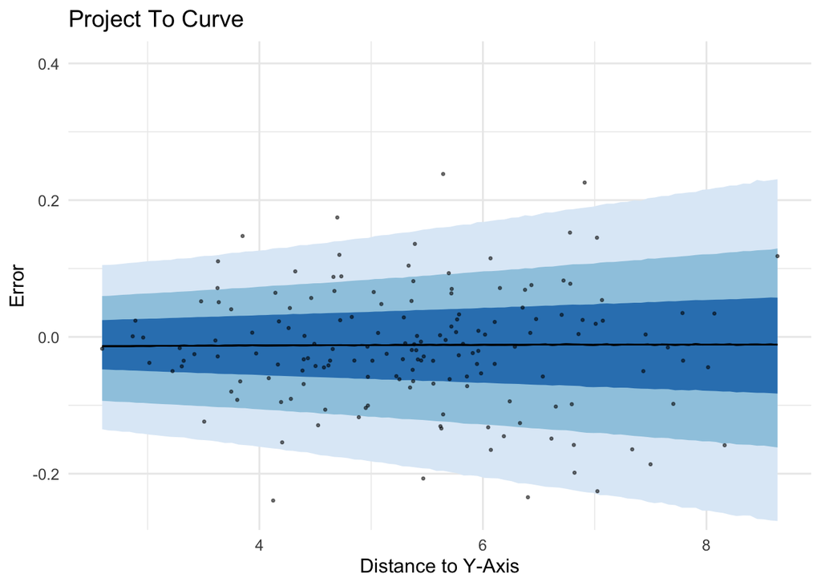

```r
prediction_grid <- task3_df %>%
  mutate(error_va = va.resp.y - va.ans.y) %>%
  data_grid(
    va.ans.x = seq_range(va.ans.x, n = 100),
    participantId = unique(participantId)
  ) %>%
  add_predicted_draws(m3)

prediction_grid %>%
  ggplot(aes(x = va.ans.x, y = .prediction)) +
  stat_lineribbon(
    .width = c(.95, .80, .50),
    # alpha = 0.5,
    linewidth = 0.5
  ) +
  scale_fill_brewer(palette = "Blues") +
  geom_point(
    data = task3_df,
    aes(y = va.resp.y - va.ans.y, x = va.ans.x),
    alpha = 0.5,
    size = 0.5
  ) +
  theme_minimal(base_size = 12) +
  theme(legend.position = "none") +
  coord_cartesian(ylim = c(-0.25, 0.4)) +
  labs(title = "Project To Curve", y = "Error", x = "Distance to Y-Axis") -> p3

p3
```